# Clustering : High Cancer risk vs Low Cancer risk for counties in California

Ambareesh Jonnavittula

27/12/2021

# Contents

- Step 1 - Problem Definition
- Step 2 - Environmental Setup
- Step 3 - Data Acquisition
- Step 4 - Data Preprocessing
- Step 5 - Exploratory Data Analysis
- Step 6 - Data Preparation & cleanup
- Step 7 - Clustering techniques
- Step 8 - Model Evaluation

# Step 1 - Problem Definition

Over the years, there have been various toxic pollutants which have caused Cancer among the people across the counties of California, USA.

The objective of this task is to be able to cluster high risk counties vs. low risk counties, or identify if there could be a third tier (moderate).

*Note - In addition, this piece of code is reproducible, hence we could scale it to any state of the USA within the dataset*

# Step 2 - Environmental Setup

- dplyr : Data manipulations
- tidyverse : Data science tasks
- readxl : to Import the .xlsx file
- skimr : Statistical summary
- corrplot : Correlation matrix
- cluster : Clustering
- factoextra : Clustering & Evaluation
- ggplot2 : Plotting graphs
- RColorBrewer : Colour palette

# Step 3 - Data Acquisition

- Import data from the file path using read_excel() function
- Rename columns for simplification

```r
## Importing / Reading the data into "df_cea_raw" data frame
df_cea_raw <- read_excel("ARM Dataset.xlsx", sheet = 1)

# Inspect the raw data
head(df_cea_raw)
```

```
## # A tibble: 6 x 17
##   State County Pollutant.Name Point..includes~ Airport.Cancer.~ OR.Lightduty..i~
##   <chr> <chr>  <chr>                     <dbl>            <dbl>            <dbl>
## 1 AK    Aleut~ ACETALDEHYDE         0                  0.000995        0.0000719
## 2 AK    Aleut~ ACETALDEHYDE         0.00000248         0.000119        0.0000206
## 3 AK    Aleut~ ACETALDEHYDE         0                  0.00561         0.000159
## 4 AK    Ancho~ ACETALDEHYDE         0.0000288          0.00465         0.0429
## 5 AK    Ancho~ ACETALDEHYDE         0.0000607          0.00267         0.0850
## 6 AK    Ancho~ ACETALDEHYDE         0.000135           0.00270         0.386
## # ... with 11 more variables: OR.Heavyduty.Cancer.Risk..per.million. <dbl>,
## #   NR..no.airports..CMV..locomotives..Cancer.Risk..per.million. <dbl>,
## #   NP.10m.ReleaseHeight.Cancer.Risk..per.million. <dbl>,
## #   NP.Low.ReleaseHeight.Cancer.Risk..per.million. <dbl>,
## #   ResidentialWoodCombustion..RWC..Cancer.Risk..per.million. <dbl>,
## #   NR.CommercialMarineVessel..CMV..Cancer.Risk..per.million. <dbl>,
## #   Biogenics.Cancer.Risk..per.million. <dbl>, ...
```

```r
tail(df_cea_raw)
```

```
## # A tibble: 6 x 17
##   State County Pollutant.Name Point..includes~ Airport.Cancer.~ OR.Lightduty..i~
##   <chr> <chr>  <chr>                     <dbl>            <dbl>            <dbl>
## 1 WY    Sweet~ TOLUENE                       0                0                0
## 2 WY    Teton  TOLUENE                       0                0                0
## 3 WY    Uinta  TOLUENE                       0                0                0
## 4 WY    Washa~ TOLUENE                       0                0                0
## 5 WY    Weston TOLUENE                       0                0                0
## 6 WY    Entir~ TOLUENE                       0                0                0
## # ... with 11 more variables: OR.Heavyduty.Cancer.Risk..per.million. <dbl>,
## #   NR..no.airports..CMV..locomotives..Cancer.Risk..per.million. <dbl>,
## #   NP.10m.ReleaseHeight.Cancer.Risk..per.million. <dbl>,
## #   NP.Low.ReleaseHeight.Cancer.Risk..per.million. <dbl>,
## #   ResidentialWoodCombustion..RWC..Cancer.Risk..per.million. <dbl>,
## #   NR.CommercialMarineVessel..CMV..Cancer.Risk..per.million. <dbl>,
## #   Biogenics.Cancer.Risk..per.million. <dbl>, ...
```

```r
names(df_cea_raw)
```

```
##  [1] "State"
##  [2] "County"
##  [3] "Pollutant.Name"
##  [4] "Point..includes.railyards..Cancer.Risk..per.million."
##  [5] "Airport.Cancer.Risk..per.million."
##  [6] "OR.Lightduty..includes.refueling..Cancer.Risk..per.million."
##  [7] "OR.Heavyduty.Cancer.Risk..per.million."
##  [8] "NR..no.airports..CMV..locomotives..Cancer.Risk..per.million."
##  [9] "NP.10m.ReleaseHeight.Cancer.Risk..per.million."
## [10] "NP.Low.ReleaseHeight.Cancer.Risk..per.million."
## [11] "ResidentialWoodCombustion..RWC..Cancer.Risk..per.million."
## [12] "NR.CommercialMarineVessel..CMV..Cancer.Risk..per.million."
## [13] "Biogenics.Cancer.Risk..per.million."
## [14] "Fires..ag..prescribed..and.wild..Cancer.Risk..per.million."
## [15] "Secondary.Cancer.Risk..per.million."
## [16] "Background.Cancer.Risk..per.million."
## [17] "Total.Cancer.Risk..per.million."
```

```r
summary(df_cea_raw)
```

```
##     State              County          Pollutant.Name
##  Length:464075      Length:464075      Length:464075
##  Class :character   Class :character   Class :character
##  Mode  :character   Mode  :character   Mode  :character
##
##
##
##  Point..includes.railyards..Cancer.Risk..per.million.
##  Min.   : 0.000000
##  1st Qu.: 0.000000
##  Median : 0.000000
##  Mean   : 0.012345
##  3rd Qu.: 0.002291
##  Max.   :14.437665
##  Airport.Cancer.Risk..per.million.
##  Min.   :0.000000
##  1st Qu.:0.000000
##  Median :0.000000
##  Mean   :0.007321
##  3rd Qu.:0.003851
##  Max.   :3.187052
##  OR.Lightduty..includes.refueling..Cancer.Risk..per.million.
##  Min.   : 0.0000
##  1st Qu.: 0.0000
##  Median : 0.0000
##  Mean   : 0.6690
##  3rd Qu.: 0.6826
##  Max.   :39.1931
##  OR.Heavyduty.Cancer.Risk..per.million.
##  Min.   :0.00000
##  1st Qu.:0.00000
##  Median :0.00000
##  Mean   :0.04181
##  3rd Qu.:0.05851
##  Max.   :5.83884
##  NR..no.airports..CMV..locomotives..Cancer.Risk..per.million.
##  Min.   : 0.0000
##  1st Qu.: 0.0000
##  Median : 0.0000
##  Mean   : 0.2424
```

[output cut: 43 more lines]

```
##  Max.   :1.85453
##  Secondary.Cancer.Risk..per.million. Background.Cancer.Risk..per.million.
##  Min.   :0.0000                      Min.   :0.000000
##  1st Qu.:0.0000                      1st Qu.:0.000000
##  Median :0.0000                      Median :0.000000
##  Mean   :0.5812                      Mean   :0.003368
##  3rd Qu.:0.0000                      3rd Qu.:0.000000
##  Max.   :6.7100                      Max.   :0.904800
##  Total.Cancer.Risk..per.million.
##  Min.   : 0.000
##  1st Qu.: 0.000
##  Median : 0.000
##  Mean   : 1.878
##  3rd Qu.: 3.486
##  Max.   :54.085
```

```r
str(df_cea_raw)
```

```
## tibble [464,075 x 17] (S3: tbl_df/tbl/data.frame)
##  $ State                                                       : chr [1:464075] "AK" "AK" "AK" "AK" ...
##  $ County                                                      : chr [1:464075] "Aleutians East Borough" "Aleutians West Census Area" "Aleutians West Census Area" "Anchorage Municipality" ...
##  $ Pollutant.Name                                              : chr [1:464075] "ACETALDEHYDE" "ACETALDEHYDE" "ACETALDEHYDE" "ACETALDEHYDE" ...
##  $ Point..includes.railyards..Cancer.Risk..per.million.        : num [1:464075] 0.00 2.48e-06 0.00 2.88e-05 6.07e-05 ...
##  $ Airport.Cancer.Risk..per.million.                           : num [1:464075] 0.000995 0.000119 0.005605 0.00465 0.002675 ...
##  $ OR.Lightduty..includes.refueling..Cancer.Risk..per.million. : num [1:464075] 7.19e-05 2.06e-05 1.59e-04 4.29e-02 8.50e-02 ...
##  $ OR.Heavyduty.Cancer.Risk..per.million.                      : num [1:464075] 6.81e-06 1.05e-05 1.43e-04 1.46e-02 3.79e-02 ...
##  $ NR..no.airports..CMV..locomotives..Cancer.Risk..per.million.: num [1:464075] 7.86e-05 1.41e-05 8.50e-05 4.14e-02 5.09e-02 ...
##  $ NP.10m.ReleaseHeight.Cancer.Risk..per.million.              : num [1:464075] 6.81e-05 1.60e-05 1.39e-04 2.17e-03 1.84e-03 ...
##  $ NP.Low.ReleaseHeight.Cancer.Risk..per.million.              : num [1:464075] 9.97e-07 1.29e-07 1.42e-06 6.16e-04 9.77e-04 ...
##  $ ResidentialWoodCombustion..RWC..Cancer.Risk..per.million.   : num [1:464075] 1.92e-05 1.05e-05 2.77e-07 7.50e-03 2.19e-02 ...
##  $ NR.CommercialMarineVessel..CMV..Cancer.Risk..per.million.   : num [1:464075] 7.75e-07 4.71e-06 5.11e-03 1.01e-04 1.00e-04 ...
##  $ Biogenics.Cancer.Risk..per.million.                         : num [1:464075] 0 0 0 0 0 0 0 0 0 0 ...
##  $ Fires..ag..prescribed..and.wild..Cancer.Risk..per.million.  : num [1:464075] 0 0 0 0 0 0 0 0 0 0 ...
##  $ Secondary.Cancer.Risk..per.million.                         : num [1:464075] 3.51 3.51 3.51 3.51 3.51 ...
##  $ Background.Cancer.Risk..per.million.                        : num [1:464075] 0 0 0 0 0 0 0 0 0 0 ...
##  $ Total.Cancer.Risk..per.million.                             : num [1:464075] 3.51 3.51 3.52 3.63 3.71 ...
```

```r
dim(df_cea_raw)
```

```
## [1] 464075     17
```

```r
# Renaming the columns as part of simplification
names(df_cea_raw)[names(df_cea_raw) == 'State'] <-  'state'
names(df_cea_raw)[names(df_cea_raw) == 'County'] <-  'county'
names(df_cea_raw)[names(df_cea_raw) == 'Pollutant.Name'] <-  'pollutant'
names(df_cea_raw)[names(df_cea_raw) == 'Point..includes.railyards..Cancer.Risk..per.million.'] <-  'railyards_crpm'
names(df_cea_raw)[names(df_cea_raw) == 'Airport.Cancer.Risk..per.million.'] <-  'airport_crpm'
names(df_cea_raw)[names(df_cea_raw) == 'OR.Lightduty..includes.refueling..Cancer.Risk..per.million.'] <-  'lightduty_crpm'
names(df_cea_raw)[names(df_cea_raw) == 'OR.Heavyduty.Cancer.Risk..per.million.'] <-  'heavyduty_crpm'
names(df_cea_raw)[names(df_cea_raw) == 'NR..no.airports..CMV..locomotives..Cancer.Risk..per.million.'] <-  'cmv_loco_crpm'
names(df_cea_raw)[names(df_cea_raw) == 'NP.10m.ReleaseHeight.Cancer.Risk..per.million.'] <-  'np_10m_releaseheight_crpm'
names(df_cea_raw)[names(df_cea_raw) == 'NP.Low.ReleaseHeight.Cancer.Risk..per.million.'] <-  'np_low_releaseheight_crpm'
names(df_cea_raw)[names(df_cea_raw) == 'ResidentialWoodCombustion..RWC..Cancer.Risk..per.million.'] <-  'rwc_crpm'
names(df_cea_raw)[names(df_cea_raw) == 'NR.CommercialMarineVessel..CMV..Cancer.Risk..per.million.'] <-  'cmv_crpm'
names(df_cea_raw)[names(df_cea_raw) == 'Biogenics.Cancer.Risk..per.million.'] <-  'biogenics_crpm'
names(df_cea_raw)[names(df_cea_raw) == 'Fires..ag..prescribed..and.wild..Cancer.Risk..per.million.'] <-  'fires_crpm'
names(df_cea_raw)[names(df_cea_raw) == 'Secondary.Cancer.Risk..per.million.'] <-  'secondary_crpm'
names(df_cea_raw)[names(df_cea_raw) == 'Total.Cancer.Risk..per.million.'] <-  'total_crpm'
```

# Step 4 - Data Preprocessing

1. Subset to a single state
2. Aggregate cancer risk data per category using averages per county

```r
# 4.1 Subset to state CA
df_cea <- select(filter(df_cea_raw, state == "CA")
                 ,c(state, county, #pollutant,
                    railyards_crpm,
                    airport_crpm,
                    lightduty_crpm,
                    heavyduty_crpm,
                    cmv_loco_crpm,
                    np_10m_releaseheight_crpm,
                    np_low_releaseheight_crpm,
                    rwc_crpm,
                    cmv_crpm,
                    biogenics_crpm,
                    fires_crpm,
                    secondary_crpm,
                    total_crpm  ))

# 4.2 Aggregate data using averages
df_cea_agg <- df_cea %>%
              group_by(state, county) %>%
              summarise_at(vars(c(1:13)), list(avg = mean))

# 4.3 Drop the raw dataframe
remove(df_cea_raw)
```

3. Inspect the subset

```r
# 4.3 Inspect the subset
# Describing the data subset
head(df_cea)
```

```
## # A tibble: 6 x 15
##   state county  railyards_crpm airport_crpm lightduty_crpm heavyduty_crpm
##   <chr> <chr>            <dbl>        <dbl>          <dbl>          <dbl>
## 1 CA    Alameda       0.000980      0.00147          0.163         0.0557
## 2 CA    Alameda       0.000911      0.00344          0.269         0.0767
## 3 CA    Alameda       0.000872      0.00384          0.277         0.0693
## 4 CA    Alameda       0.000740      0.00424          0.247         0.0662
## 5 CA    Alameda       0.000836      0.00409          0.260         0.0707
## 6 CA    Alameda       0.000923      0.00410          0.278         0.114
## # ... with 9 more variables: cmv_loco_crpm <dbl>,
## #   np_10m_releaseheight_crpm <dbl>, np_low_releaseheight_crpm <dbl>,
## #   rwc_crpm <dbl>, cmv_crpm <dbl>, biogenics_crpm <dbl>, fires_crpm <dbl>,
## #   secondary_crpm <dbl>, total_crpm <dbl>
```

```r
tail(df_cea)
```

```
## # A tibble: 6 x 15
##   state county       railyards_crpm airport_crpm lightduty_crpm heavyduty_crpm
##   <chr> <chr>                 <dbl>        <dbl>          <dbl>          <dbl>
## 1 CA    Tulare                    0            0              0              0
## 2 CA    Tuolumne                  0            0              0              0
## 3 CA    Ventura                   0            0              0              0
## 4 CA    Yolo                      0            0              0              0
## 5 CA    Yuba                      0            0              0              0
## 6 CA    Entire state              0            0              0              0
## # ... with 9 more variables: cmv_loco_crpm <dbl>,
## #   np_10m_releaseheight_crpm <dbl>, np_low_releaseheight_crpm <dbl>,
## #   rwc_crpm <dbl>, cmv_crpm <dbl>, biogenics_crpm <dbl>, fires_crpm <dbl>,
## #   secondary_crpm <dbl>, total_crpm <dbl>
```

```r
names(df_cea)
```

```
##  [1] "state"                     "county"
##  [3] "railyards_crpm"            "airport_crpm"
##  [5] "lightduty_crpm"            "heavyduty_crpm"
##  [7] "cmv_loco_crpm"             "np_10m_releaseheight_crpm"
##  [9] "np_low_releaseheight_crpm" "rwc_crpm"
## [11] "cmv_crpm"                  "biogenics_crpm"
## [13] "fires_crpm"                "secondary_crpm"
## [15] "total_crpm"
```

```r
str(df_cea)
```

```
## tibble [48,781 x 15] (S3: tbl_df/tbl/data.frame)
##  $ state                    : chr [1:48781] "CA" "CA" "CA" "CA" ...
##  $ county                   : chr [1:48781] "Alameda" "Alameda" "Alameda" "Alameda" ...
##  $ railyards_crpm           : num [1:48781] 0.00098 0.000911 0.000872 0.00074 0.000836 ...
##  $ airport_crpm             : num [1:48781] 0.00147 0.00344 0.00384 0.00424 0.00409 ...
##  $ lightduty_crpm           : num [1:48781] 0.163 0.269 0.277 0.247 0.26 ...
##  $ heavyduty_crpm           : num [1:48781] 0.0557 0.0767 0.0693 0.0662 0.0707 ...
##  $ cmv_loco_crpm            : num [1:48781] 0.0922 0.1639 0.1774 0.1927 0.202 ...
##  $ np_10m_releaseheight_crpm: num [1:48781] 0.00985 0.01704 0.0179 0.01742 0.02013 ...
##  $ np_low_releaseheight_crpm: num [1:48781] 0.0152 0.0178 0.0186 0.0183 0.0196 ...
##  $ rwc_crpm                 : num [1:48781] 0.0806 0.1339 0.0916 0.0661 0.0707 ...
##  $ cmv_crpm                 : num [1:48781] 0.0323 0.0668 0.0727 0.0726 0.0799 ...
##  $ biogenics_crpm           : num [1:48781] 0.191 0.191 0.187 0.167 0.183 ...
##  $ fires_crpm               : num [1:48781] 0.00572 0.00572 0.00555 0.00478 0.00543 ...
##  $ secondary_crpm           : num [1:48781] 1.82 1.82 1.81 1.74 1.79 ...
##  $ total_crpm               : num [1:48781] 2.47 2.77 2.73 2.59 2.71 ...
```

```r
summary(df_cea)
```

```
##     state              county          railyards_crpm      airport_crpm
##  Length:48781       Length:48781       Min.   :0.000000   Min.   :0.000000
##  Class :character   Class :character   1st Qu.:0.000000   1st Qu.:0.000000
##  Mode  :character   Mode  :character   Median :0.000000   Median :0.000000
##                                        Mean   :0.011944   Mean   :0.013268
##                                        3rd Qu.:0.003741   3rd Qu.:0.008122
##                                        Max.   :3.442458   Max.   :3.171625
##  lightduty_crpm    heavyduty_crpm    cmv_loco_crpm    np_10m_releaseheight_crpm
##  Min.   : 0.0000   Min.   :0.00000   Min.   :0.0000   Min.   :0.000000
##  1st Qu.: 0.0000   1st Qu.:0.00000   1st Qu.:0.0000   1st Qu.:0.000000
##  Median : 0.0000   Median :0.00000   Median :0.0000   Median :0.000000
##  Mean   : 0.6803   Mean   :0.04062   Mean   :0.2645   Mean   :0.019678
##  3rd Qu.: 0.7417   3rd Qu.:0.06726   3rd Qu.:0.3574   3rd Qu.:0.002335
##  Max.   :20.7623   Max.   :1.36491   Max.   :8.9037   Max.   :1.817212
##  np_low_releaseheight_crpm    rwc_crpm         cmv_crpm
##  Min.   :0.00000           Min.   :0.0000   Min.   :0.000000
##  1st Qu.:0.00000           1st Qu.:0.0000   1st Qu.:0.000000
##  Median :0.00000           Median :0.0000   Median :0.000000
##  Mean   :0.05021           Mean   :0.1095   Mean   :0.004038
##  3rd Qu.:0.02407           3rd Qu.:0.1191   3rd Qu.:0.001599
##  Max.   :3.12849           Max.   :3.9761   Max.   :1.607277
##  biogenics_crpm      fires_crpm      secondary_crpm     total_crpm
##  Min.   :0.00000   Min.   :0.00000   Min.   :0.0000   Min.   : 0.000
##  1st Qu.:0.00000   1st Qu.:0.00000   1st Qu.:0.0000   1st Qu.: 0.000
##  Median :0.00000   Median :0.00000   Median :0.0000   Median : 0.000
##  Mean   :0.05655   Mean   :0.02688   Mean   :0.4693   Mean   : 1.747
##  3rd Qu.:0.00000   3rd Qu.:0.02017   3rd Qu.:0.0000   3rd Qu.: 3.337
##  Max.   :1.73213   Max.   :0.60468   Max.   :5.0955   Max.   :32.842
```

```r
# Check the number of Rows & Columns in the data subset
nrow(df_cea)
```

```
## [1] 48781
```

```r
ncol(df_cea)
```

```
## [1] 15
```

```r
dim(df_cea)
```

```
## [1] 48781    15
```

```r
skim(df_cea)
```

Data summary

| Name | df_cea |
| --- | --- |
| Number of rows | 48781 |
| Number of columns | 15 |
| _______________________ |  |
| Column type frequency: |  |
| character | 2 |
| numeric | 13 |
| ________________________ |  |
| Group variables | None |

**Variable type: character**

| skim_variable | n_missing | complete_rate | min | max | empty | n_unique | whitespace |
| --- | --- | --- | --- | --- | --- | --- | --- |
| state | 0 | 1 | 2 | 2 | 0 | 1 | 0 |
| county | 0 | 1 | 4 | 15 | 0 | 59 | 0 |

**Variable type: numeric**

| skim_variable | n_missing | complete_rate | mean | sd | p0 | p25 | p50 | p75 | p100 | hist |
| --- | --- | --- | --- | --- | --- | --- | --- | --- | --- | --- |
| railyards_crpm | 0 | 1 | 0.01 | 0.06 | 0 | 0 | 0 | 0.00 | 3.44 | ▇▁▁▁▁ |
| airport_crpm | 0 | 1 | 0.01 | 0.06 | 0 | 0 | 0 | 0.01 | 3.17 | ▇▁▁▁▁ |
| lightduty_crpm | 0 | 1 | 0.68 | 1.34 | 0 | 0 | 0 | 0.74 | 20.76 | ▇▁▁▁▁ |
| heavyduty_crpm | 0 | 1 | 0.04 | 0.06 | 0 | 0 | 0 | 0.07 | 1.36 | ▇▁▁▁▁ |
| cmv_loco_crpm | 0 | 1 | 0.26 | 0.48 | 0 | 0 | 0 | 0.36 | 8.90 | ▇▁▁▁▁ |
| np_10m_releaseheight_crpm | 0 | 1 | 0.02 | 0.06 | 0 | 0 | 0 | 0.00 | 1.82 | ▇▁▁▁▁ |
| np_low_releaseheight_crpm | 0 | 1 | 0.05 | 0.13 | 0 | 0 | 0 | 0.02 | 3.13 | ▇▁▁▁▁ |
| rwc_crpm | 0 | 1 | 0.11 | 0.27 | 0 | 0 | 0 | 0.12 | 3.98 | ▇▁▁▁▁ |
| cmv_crpm | 0 | 1 | 0.00 | 0.02 | 0 | 0 | 0 | 0.00 | 1.61 | ▇▁▁▁▁ |
| biogenics_crpm | 0 | 1 | 0.06 | 0.15 | 0 | 0 | 0 | 0.00 | 1.73 | ▇▁▁▁▁ |
| fires_crpm | 0 | 1 | 0.03 | 0.06 | 0 | 0 | 0 | 0.02 | 0.60 | ▇▁▁▁▁ |
| secondary_crpm | 0 | 1 | 0.47 | 1.09 | 0 | 0 | 0 | 0.00 | 5.10 | ▇▁▁▁▁ |
| total_crpm | 0 | 1 | 1.75 | 2.37 | 0 | 0 | 0 | 3.34 | 32.84 | ▇▁▁▁▁ |

```r
# Describing the data subset
head(df_cea_agg)
```

```
## # A tibble: 6 x 15
## # Groups:   state [1]
##   state county    railyards_crpm_avg airport_crpm_avg lightduty_crpm_avg
##   <chr> <chr>                  <dbl>            <dbl>              <dbl>
## 1 CA    Alameda          0.0181             0.0114                0.760
## 2 CA    Alpine           0.000000926        0.0000301             0.0280
## 3 CA    Amador           0.000152           0.00161               0.124
## 4 CA    Butte            0.00299            0.00270               0.375
## 5 CA    Calaveras        0.000352           0.000432              0.0767
## 6 CA    Colusa           0.00536            0.00226               0.0528
## # ... with 10 more variables: heavyduty_crpm_avg <dbl>,
## #   cmv_loco_crpm_avg <dbl>, np_10m_releaseheight_crpm_avg <dbl>,
## #   np_low_releaseheight_crpm_avg <dbl>, rwc_crpm_avg <dbl>,
## #   cmv_crpm_avg <dbl>, biogenics_crpm_avg <dbl>, fires_crpm_avg <dbl>,
## #   secondary_crpm_avg <dbl>, total_crpm_avg <dbl>
```

```r
tail(df_cea_agg)
```

```
## # A tibble: 6 x 15
## # Groups:   state [1]
##   state county   railyards_crpm_avg airport_crpm_avg lightduty_crpm_avg
##   <chr> <chr>                 <dbl>            <dbl>              <dbl>
## 1 CA    Trinity            0.000483          0.00198             0.0273
## 2 CA    Tulare             0.0106            0.00267             0.466
## 3 CA    Tuolumne           0.000716          0.00256             0.133
## 4 CA    Ventura            0.00402           0.00302             0.398
## 5 CA    Yolo               0.00360           0.00520             0.455
## 6 CA    Yuba               0.00638           0.00374             0.290
## # ... with 10 more variables: heavyduty_crpm_avg <dbl>,
## #   cmv_loco_crpm_avg <dbl>, np_10m_releaseheight_crpm_avg <dbl>,
## #   np_low_releaseheight_crpm_avg <dbl>, rwc_crpm_avg <dbl>,
## #   cmv_crpm_avg <dbl>, biogenics_crpm_avg <dbl>, fires_crpm_avg <dbl>,
## #   secondary_crpm_avg <dbl>, total_crpm_avg <dbl>
```

```r
names(df_cea_agg)
```

```
##  [1] "state"                         "county"
##  [3] "railyards_crpm_avg"            "airport_crpm_avg"
##  [5] "lightduty_crpm_avg"            "heavyduty_crpm_avg"
##  [7] "cmv_loco_crpm_avg"             "np_10m_releaseheight_crpm_avg"
##  [9] "np_low_releaseheight_crpm_avg" "rwc_crpm_avg"
## [11] "cmv_crpm_avg"                  "biogenics_crpm_avg"
## [13] "fires_crpm_avg"                "secondary_crpm_avg"
## [15] "total_crpm_avg"
```

```r
str(df_cea_agg)
```

```
## grouped_df [59 x 15] (S3: grouped_df/tbl_df/tbl/data.frame)
##  $ state                        : chr [1:59] "CA" "CA" "CA" "CA" ...
##  $ county                       : chr [1:59] "Alameda" "Alpine" "Amador" "Butte" ...
##  $ railyards_crpm_avg           : num [1:59] 1.81e-02 9.26e-07 1.52e-04 2.99e-03 3.52e-04 ...
##  $ airport_crpm_avg             : num [1:59] 1.14e-02 3.01e-05 1.61e-03 2.70e-03 4.32e-04 ...
##  $ lightduty_crpm_avg           : num [1:59] 0.76 0.028 0.1243 0.3752 0.0767 ...
##  $ heavyduty_crpm_avg           : num [1:59] 0.05733 0.00088 0.00507 0.01827 0.00334 ...
##  $ cmv_loco_crpm_avg            : num [1:59] 0.2796 0.0173 0.0868 0.1312 0.1138 ...
##  $ np_10m_releaseheight_crpm_avg: num [1:59] 0.04425 0.00255 0.01733 0.01758 0.01431 ...
##  $ np_low_releaseheight_crpm_avg: num [1:59] 0.039641 0.000517 0.003976 0.021578 0.001931 ...
##  $ rwc_crpm_avg                 : num [1:59] 0.10183 0.00783 0.06 0.25419 0.04439 ...
##  $ cmv_crpm_avg                 : num [1:59] 1.97e-02 3.89e-05 4.22e-06 6.73e-12 9.29e-06 ...
##  $ biogenics_crpm_avg           : num [1:59] 0.0339 0.0406 0.1143 0.1226 0.1032 ...
##  $ fires_crpm_avg               : num [1:59] 0.0246 0.058 0.0751 0.0807 0.0776 ...
##  $ secondary_crpm_avg           : num [1:59] 0.304 0.319 0.55 0.664 0.53 ...
##  $ total_crpm_avg               : num [1:59] 1.694 0.475 1.038 1.691 0.966 ...
##  - attr(*, "groups")= tibble [1 x 2] (S3: tbl_df/tbl/data.frame)
##   ..$ state: chr "CA"
##   ..$ .rows: list<int> [1:1]
##   .. ..$ : int [1:59] 1 2 3 4 5 6 7 8 9 10 ...
##   .. ..@ ptype: int(0)
##   ..- attr(*, ".drop")= logi TRUE
```

```r
summary(df_cea_agg)
```

```
##     state              county          railyards_crpm_avg  airport_crpm_avg
##  Length:59          Length:59          Min.   :9.300e-07   Min.   :3.006e-05
##  Class :character   Class :character   1st Qu.:1.694e-03   1st Qu.:1.495e-03
##  Mode  :character   Mode  :character   Median :4.213e-03   Median :2.381e-03
##                                        Mean   :8.070e-03   Mean   :3.829e-03
##                                        3rd Qu.:6.711e-03   3rd Qu.:3.698e-03
##                                        Max.   :5.241e-02   Max.   :3.047e-02
##  lightduty_crpm_avg heavyduty_crpm_avg  cmv_loco_crpm_avg
##  Min.   :0.02727    Min.   :0.0008799   Min.   :0.01731
##  1st Qu.:0.15831    1st Qu.:0.0077556   1st Qu.:0.07572
##  Median :0.37522    Median :0.0190867   Median :0.11629
##  Mean   :0.37114    Mean   :0.0228742   Mean   :0.14111
##  3rd Qu.:0.46576    3rd Qu.:0.0367788   3rd Qu.:0.16001
##  Max.   :1.77834    Max.   :0.0671986   Max.   :0.73445
##  np_10m_releaseheight_crpm_avg np_low_releaseheight_crpm_avg  rwc_crpm_avg
##  Min.   :0.002551              Min.   :0.0005167             Min.   :0.005392
##  1st Qu.:0.008407              1st Qu.:0.0059145             1st Qu.:0.055422
##  Median :0.017581              Median :0.0208691             Median :0.083522
##  Mean   :0.024120              Mean   :0.0250474             Mean   :0.110702
##  3rd Qu.:0.032040              3rd Qu.:0.0353419             3rd Qu.:0.127085
##  Max.   :0.128614              Max.   :0.1458729             Max.   :0.630305
##   cmv_crpm_avg       biogenics_crpm_avg fires_crpm_avg    secondary_crpm_avg
##  Min.   :0.000e+00   Min.   :0.02950    Min.   :0.01081   Min.   :0.2234
##  1st Qu.:0.000e+00   1st Qu.:0.06072    1st Qu.:0.02697   1st Qu.:0.3193
##  Median :2.084e-05   Median :0.08265    Median :0.04486   Median :0.4522
##  Mean   :1.882e-03   Mean   :0.08291    Mean   :0.04895   Mean   :0.4441
##  3rd Qu.:5.624e-04   3rd Qu.:0.10364    3rd Qu.:0.06455   3rd Qu.:0.5459
##  Max.   :4.976e-02   Max.   :0.14315    Max.   :0.12878   Max.   :0.6755
##  total_crpm_avg
##  Min.   :0.3853
##  1st Qu.:0.9822
##  Median :1.2705
##  Mean   :1.2848
##  3rd Qu.:1.6208
##  Max.   :3.2576
```

```r
# Check the number of Rows & Columns in the data subset
nrow(df_cea_agg)
```

```
## [1] 59
```

```r
ncol(df_cea_agg)
```

```
## [1] 15
```

```r
dim(df_cea_agg)
```

```
## [1] 59 15
```

```r
skim(df_cea_agg)
```

Data summary

| Name | df_cea_agg |
| --- | --- |
| Number of rows | 59 |
| Number of columns | 15 |
| _______________________ |  |
| Column type frequency: |  |
| character | 1 |
| numeric | 13 |
| ________________________ |  |
| Group variables | state |

**Variable type: character**

| skim_variable | state | n_missing | complete_rate | min | max | empty | n_unique | whitespace |
| --- | --- | --- | --- | --- | --- | --- | --- | --- |
| county | CA | 0 | 1 | 4 | 15 | 0 | 59 | 0 |

**Variable type: numeric**

| skim_variable | state | n_missing | complete_rate | mean | sd | p0 | p25 | p50 | p75 | p100 | hist |
| --- | --- | --- | --- | --- | --- | --- | --- | --- | --- | --- | --- |
| railyards_crpm_avg | CA | 0 | 1 | 0.01 | 0.01 | 0.00 | 0.00 | 0.00 | 0.01 | 0.05 | ▇▁▁▁▁ |
| airport_crpm_avg | CA | 0 | 1 | 0.00 | 0.01 | 0.00 | 0.00 | 0.00 | 0.00 | 0.03 | ▇▁▁▁▁ |
| lightduty_crpm_avg | CA | 0 | 1 | 0.37 | 0.29 | 0.03 | 0.16 | 0.38 | 0.47 | 1.78 | ▇▅▁▁▁ |
| heavyduty_crpm_avg | CA | 0 | 1 | 0.02 | 0.02 | 0.00 | 0.01 | 0.02 | 0.04 | 0.07 | ▇▅▆▂▁ |
| cmv_loco_crpm_avg | CA | 0 | 1 | 0.14 | 0.11 | 0.02 | 0.08 | 0.12 | 0.16 | 0.73 | ▇▂▁▁▁ |
| np_10m_releaseheight_crpm_avg | CA | 0 | 1 | 0.02 | 0.02 | 0.00 | 0.01 | 0.02 | 0.03 | 0.13 | ▇▂▁▁▁ |
| np_low_releaseheight_crpm_avg | CA | 0 | 1 | 0.03 | 0.02 | 0.00 | 0.01 | 0.02 | 0.04 | 0.15 | ▇▃▁▁▁ |
| rwc_crpm_avg | CA | 0 | 1 | 0.11 | 0.10 | 0.01 | 0.06 | 0.08 | 0.13 | 0.63 | ▇▂▁▁▁ |
| cmv_crpm_avg | CA | 0 | 1 | 0.00 | 0.01 | 0.00 | 0.00 | 0.00 | 0.00 | 0.05 | ▇▁▁▁▁ |
| biogenics_crpm_avg | CA | 0 | 1 | 0.08 | 0.03 | 0.03 | 0.06 | 0.08 | 0.10 | 0.14 | ▆▇▇▇▅ |
| fires_crpm_avg | CA | 0 | 1 | 0.05 | 0.03 | 0.01 | 0.03 | 0.04 | 0.06 | 0.13 | ▇▅▆▂▁ |
| secondary_crpm_avg | CA | 0 | 1 | 0.44 | 0.13 | 0.22 | 0.32 | 0.45 | 0.55 | 0.68 | ▆▅▃▇▃ |
| total_crpm_avg | CA | 0 | 1 | 1.28 | 0.49 | 0.39 | 0.98 | 1.27 | 1.62 | 3.26 | ▅▇▅▁▁ |

3. Custom function to normalize the data

```r
#normalise function
normalise <- function(df)
{
  return(((df- min(df)) /(max(df)-min(df))*(1-0))+0)
}
```

# Step 5 - Exploratory Data Analysis

1. Correlation plots with Pearson correlation coefficients

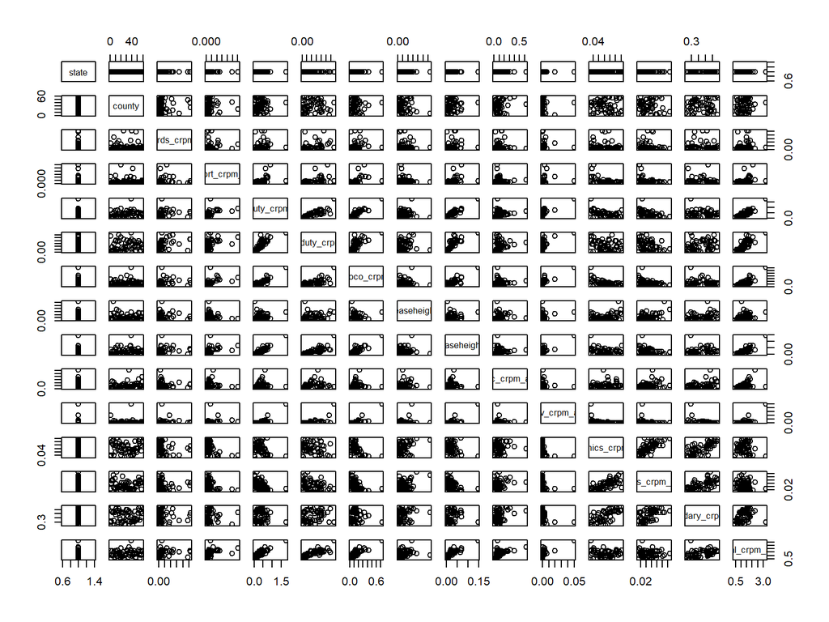

```r
# Pairs plot - Correlation plot
df_cea_agg$state <- as.factor(df_cea_agg$state)
df_cea_agg$county <- as.factor(df_cea_agg$county)
pairs(df_cea_agg)
```

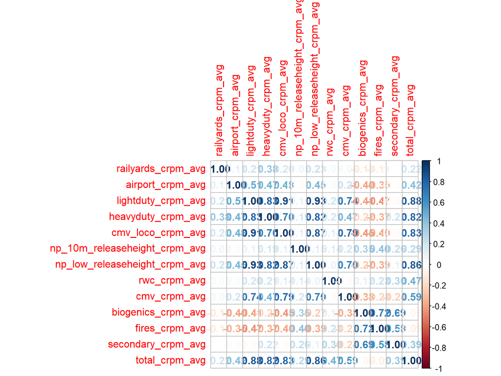

```r
rownames(df_cea_agg) <- df_cea_agg$county

corrmatrix <- cor(df_cea_agg[,3:15])
corrplot(corrmatrix, method = 'number')
```

From above outcomes, we can deduce that the average total CRPM has strong correlations with averages of light duty crpm, heavy duty crpm, cmv loco crpm & np_low_release height crpm.

2. Strong Correlations (based on EDA)

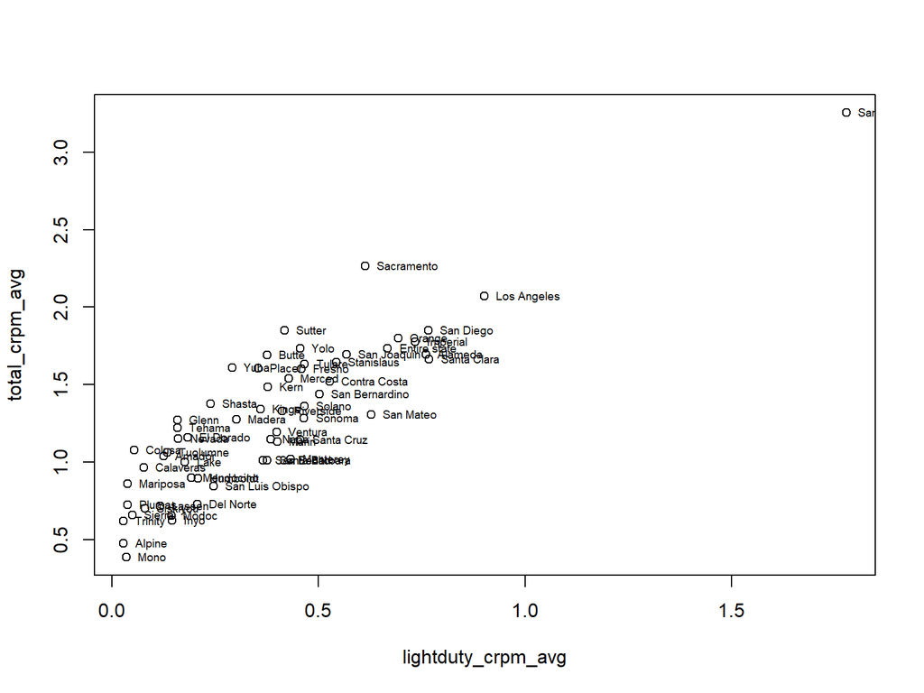

```r
# Total CRPM avg vs. Light duty CRPM avg
plot(total_crpm_avg ~ lightduty_crpm_avg, data = df_cea_agg)
with(df_cea_agg,text(total_crpm_avg ~ lightduty_crpm_avg, labels= county,pos=4,cex=.6))
```

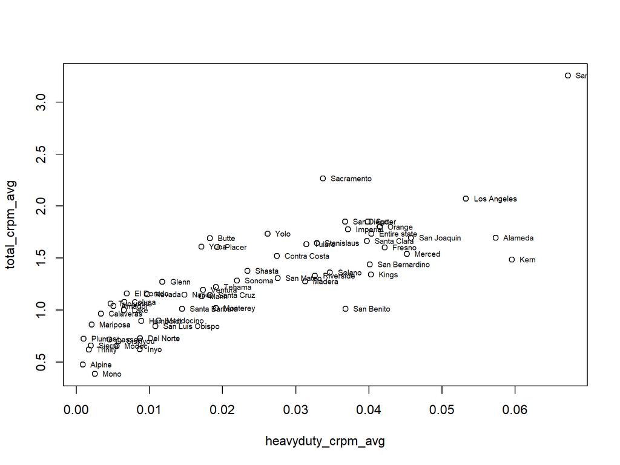

```r
# Total CRPM avg vs. Heavy duty CRPM avg
plot(total_crpm_avg ~ heavyduty_crpm_avg, data = df_cea_agg)
with(df_cea_agg,text(total_crpm_avg ~ heavyduty_crpm_avg, labels= county,pos=4,cex=.6))
```

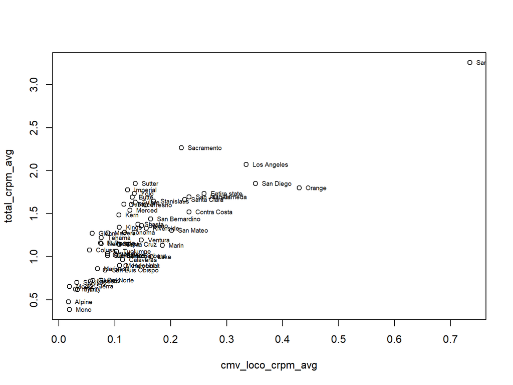

```r
# Total CRPM avg vs. CMV_Loco_CRPM_avg
plot(total_crpm_avg ~ cmv_loco_crpm_avg, data = df_cea_agg)
with(df_cea_agg,text(total_crpm_avg ~ cmv_loco_crpm_avg, labels= county,pos=4,cex=.6))
```

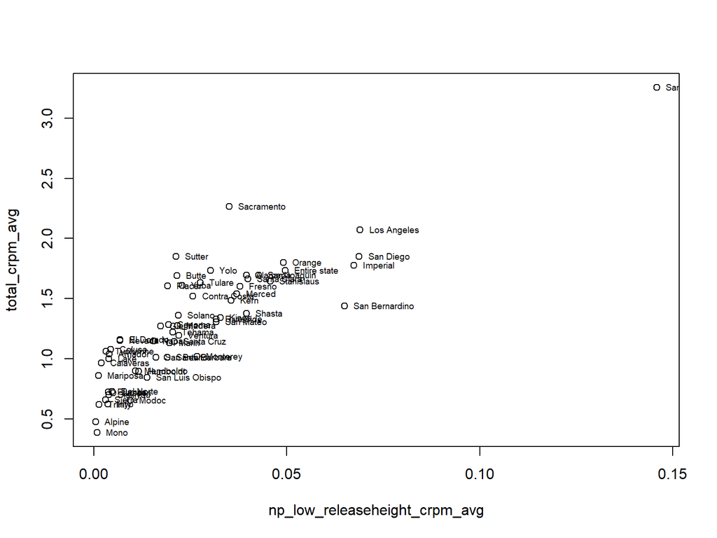

```r
# Total CRPM avg vs. np_low_release_Height_crpm_avg
plot(total_crpm_avg ~ np_low_releaseheight_crpm_avg, data = df_cea_agg)
with(df_cea_agg,text(total_crpm_avg ~ np_low_releaseheight_crpm_avg, labels= county,pos=4,cex=.6))
```

# Step 6 - Data Preparation & clean-up

1. Normalize all the continuous CRPM variables.
2. Inspect the normalized dataset.

```r
# 6.1.1 Separate the county
df_cea_agg$county <- as.character(df_cea_agg$county)
county <- df_cea_agg[,2]
county
```

```
## # A tibble: 59 x 1
##    county
##    <chr>
##  1 Alameda
##  2 Alpine
##  3 Amador
##  4 Butte
##  5 Calaveras
##  6 Colusa
##  7 Contra Costa
##  8 Del Norte
##  9 El Dorado
## 10 Entire state
## # ... with 49 more rows
```

```r
# 6.1.2 Normalise the dataset using the custom created function
df_cea_agg_n <- as.data.frame(lapply(df_cea_agg[,3:15] ,normalise))

# 6.1.3 Merge with County, apply rownames & sort by County
df_cea_agg_n <- cbind(county, df_cea_agg_n)
rownames(df_cea_agg_n)<-df_cea_agg_n$county
df_cea_agg_n <- df_cea_agg_n[order(county),]

# 6.2 Inspect the normalized dataset
dim(df_cea_agg_n)
```

```
## [1] 59 14
```

```r
str(df_cea_agg_n)
```

```
## 'data.frame':    59 obs. of  14 variables:
##  $ county                       : chr  "Alameda" "Alpine" "Amador" "Butte" ...
##  $ railyards_crpm_avg           : num  0.34452 0 0.00287 0.05702 0.00669 ...
##  $ airport_crpm_avg             : num  0.3723 0 0.0519 0.0876 0.0132 ...
##  $ lightduty_crpm_avg           : num  0.418447 0.000396 0.055416 0.198708 0.028218 ...
##  $ heavyduty_crpm_avg           : num  0.8512 0 0.0631 0.2623 0.0371 ...
##  $ cmv_loco_crpm_avg            : num  0.3657 0 0.0969 0.1588 0.1345 ...
##  $ np_10m_releaseheight_crpm_avg: num  0.3308 0 0.1172 0.1192 0.0933 ...
##  $ np_low_releaseheight_crpm_avg: num  0.26917 0 0.0238 0.1449 0.00973 ...
##  $ rwc_crpm_avg                 : num  0.15433 0.00391 0.08739 0.39814 0.0624 ...
##  $ cmv_crpm_avg                 : num  3.95e-01 7.83e-04 8.48e-05 1.35e-10 1.87e-04 ...
##  $ biogenics_crpm_avg           : num  0.0384 0.0977 0.7461 0.8191 0.6485 ...
##  $ fires_crpm_avg               : num  0.117 0.4 0.545 0.593 0.567 ...
##  $ secondary_crpm_avg           : num  0.178 0.211 0.722 0.974 0.678 ...
##  $ total_crpm_avg               : num  0.4556 0.0311 0.2274 0.4545 0.2022 ...
```

```r
names(df_cea_agg_n)
```

```
##  [1] "county"                        "railyards_crpm_avg"
##  [3] "airport_crpm_avg"              "lightduty_crpm_avg"
##  [5] "heavyduty_crpm_avg"            "cmv_loco_crpm_avg"
##  [7] "np_10m_releaseheight_crpm_avg" "np_low_releaseheight_crpm_avg"
##  [9] "rwc_crpm_avg"                  "cmv_crpm_avg"
## [11] "biogenics_crpm_avg"            "fires_crpm_avg"
## [13] "secondary_crpm_avg"            "total_crpm_avg"
```

```r
head(df_cea_agg_n)
```

```
##              county railyards_crpm_avg airport_crpm_avg lightduty_crpm_avg
## Alameda     Alameda        0.344518322       0.37232869       0.4184474080
## Alpine       Alpine        0.000000000       0.00000000       0.0003956916
## Amador       Amador        0.002874408       0.05194557       0.0554159414
## Butte         Butte        0.057022641       0.08763879       0.1987080260
## Calaveras Calaveras        0.006694936       0.01319304       0.0282184353
## Colusa       Colusa        0.102207712       0.07336873       0.0145661413
##           heavyduty_crpm_avg cmv_loco_crpm_avg np_10m_releaseheight_crpm_avg
## Alameda           0.85123603        0.36569978                    0.33076731
## Alpine            0.00000000        0.00000000                    0.00000000
## Amador            0.06312473        0.09694094                    0.11720072
## Butte             0.26226641        0.15884290                    0.11922039
## Calaveras         0.03714618        0.13453312                    0.09331456
## Colusa            0.08574494        0.05249649                    1.00000000
##           np_low_releaseheight_crpm_avg rwc_crpm_avg cmv_crpm_avg
## Alameda                     0.269165098  0.154328078 3.952665e-01
## Alpine                      0.000000000  0.003907004 7.826647e-04
## Amador                      0.023797836  0.087387815 8.482287e-05
## Butte                       0.144896934  0.398137537 1.352619e-10
## Calaveras                   0.009732264  0.062401324 1.866267e-04
## Colusa                      0.026344514  0.079080111 2.936479e-06
##           biogenics_crpm_avg fires_crpm_avg secondary_crpm_avg total_crpm_avg
## Alameda           0.03837968      0.1165237          0.1776994     0.45558609
## Alpine            0.09765022      0.4003690          0.2114146     0.03113551
## Amador            0.74606773      0.5450482          0.7217199     0.22735977
## Butte             0.81905193      0.5926266          0.9740823     0.45452513
## Calaveras         0.64849745      0.5665631          0.6779681     0.20216598
## Colusa            0.88490464      0.8289152          0.6726941     0.24042289
```

```r
tail(df_cea_agg_n)
```

```
##            county railyards_crpm_avg airport_crpm_avg lightduty_crpm_avg
## Trinity   Trinity        0.009204627       0.06406113         0.00000000
## Tulare     Tulare        0.202612354       0.08657889         0.25074837
## Tuolumne Tuolumne        0.013637413       0.08326433         0.06044984
## Ventura   Ventura        0.076695578       0.09833779         0.21192065
## Yolo         Yolo        0.068674435       0.16978159         0.24426675
## Yuba         Yuba        0.121810278       0.12177294         0.15023029
##          heavyduty_crpm_avg cmv_loco_crpm_avg np_10m_releaseheight_crpm_avg
## Trinity          0.01210618         0.0225645                    0.02949118
## Tulare           0.46076292         0.1667213                    0.02018913
## Tuolumne         0.05701242         0.1195550                    0.16115035
## Ventura          0.24809238         0.1817530                    0.04971938
## Yolo             0.38109649         0.1642765                    0.16048437
## Yuba             0.24452736         0.1380236                    0.37752590
##          np_low_releaseheight_crpm_avg rwc_crpm_avg cmv_crpm_avg
## Trinity                    0.005548961   0.01345188 0.0001076804
## Tulare                     0.186622924   0.12652735 0.0000000000
## Tuolumne                   0.018197434   0.12502619 0.0000000000
## Ventura                    0.148124422   0.14715611 0.0436666207
## Yolo                       0.204559259   0.62688560 0.0473882689
## Yuba                       0.153749418   0.36212168 0.0001313356
##          biogenics_crpm_avg fires_crpm_avg secondary_crpm_avg total_crpm_avg
## Trinity           0.6978581     0.57062807          0.2702909     0.08130371
## Tulare            0.9085811     0.41868165          1.0000000     0.43459552
## Tuolumne          0.6011635     0.48755328          0.7046937     0.23552026
## Ventura           0.3058607     0.08494616          0.4099142     0.28175553
## Yolo              0.5493119     0.42985914          0.6203777     0.46987481
## Yuba              0.8334969     0.66601249          0.9563634     0.42565499
```

3. Create and analyze the distance between spatial points using the Euclidean method, and create a distance matrix

```r
# 6.3.1 Choosing Euclidean distance method and creating distance matrix
distance <- dist(df_cea_agg_n,method = "euclidean")
print(distance,digits=3)
```

```
##                 Alameda Alpine Amador Butte Calaveras Colusa Contra Costa
## Alpine            1.436
## Amador            1.589  0.917
## Butte             1.590  1.334  0.571
## Calaveras         1.570  0.811  0.140 0.657
## Colusa            1.850  1.501  0.982 1.121     1.023
## Contra Costa      0.772  1.155  1.316 1.362     1.280  1.575
## Del Norte         1.274  0.586  0.902 1.269     0.853  1.404        0.994
## El Dorado         1.515  0.880  0.262 0.544     0.260  0.921        1.230
## Entire state      0.669  1.223  1.152 1.096     1.153  1.609        0.792
## Fresno            1.189  1.255  0.770 0.575     0.817  1.332        1.139
## Glenn             1.828  1.431  0.733 0.769     0.795  0.529        1.590
## Humboldt          1.178  0.789  0.907 1.200     0.878  1.260        0.796
## Imperial          1.401  1.543  0.963 0.834     1.050  1.287        1.360
## Inyo              1.295  0.398  0.857 1.246     0.792  1.472        1.046
## Kern              1.197  1.569  1.147 1.009     1.197  1.292        1.120
## Kings             1.280  1.205  0.683 0.639     0.744  1.299        1.194
## Lake              1.273  0.603  0.524 0.887     0.465  1.148        0.947
## Lassen            1.299  0.399  0.707 1.100     0.633  1.339        0.955
## Los Angeles       0.996  1.810  1.742 1.624     1.756  2.119        1.361
## Madera            1.238  1.060  0.540 0.599     0.586  0.919        1.069
## Marin             0.970  0.633  0.979 1.208     0.920  1.540        0.744
## Mariposa          1.680  0.830  0.320 0.761     0.244  1.062        1.402
## Mendocino         1.276  0.734  0.706 1.037     0.690  1.221        1.026
## Merced            1.249  1.554  1.294 1.175     1.312  1.613        0.931
## Modoc             1.296  0.317  0.770 1.173     0.698  1.362        1.048
## Mono              1.393  0.325  1.152 1.543     1.060  1.703        1.143
## Monterey          0.977  0.653  1.077 1.320     1.026  1.596        0.785
## Napa              1.140  0.591  0.681 0.930     0.635  1.344        0.887
## Nevada            1.557  1.010  0.199 0.466     0.298  1.002        1.283
## Orange            0.696  1.298  1.373 1.359     1.346  1.866        0.890
## Placer            1.349  1.141  0.588 0.380     0.630  0.991        1.080
## Plumas            1.516  0.619  0.398 0.896     0.341  1.180        1.214
## Riverside         1.085  0.987  0.784 0.845     0.788  1.462        1.005
## Sacramento        1.385  1.586  1.271 0.892     1.301  1.649        1.241
## San Benito        0.868  0.797  1.014 1.211     0.984  1.459        0.760
## San Bernardino    0.915  1.111  1.059 1.056     1.054  1.623        0.942
## San Diego         0.641  1.379  1.425 1.393     1.411  1.801        0.684
## San Francisco     1.499  2.590  2.595 2.461     2.588  2.759        1.965
## San Joaquin       1.030  1.526  1.405 1.316     1.402  1.681        0.675
```

[output cut: 476 more lines]

```
## Santa Cruz
## Shasta
## Sierra
## Siskiyou
## Solano
## Sonoma
## Stanislaus
## Sutter
## Tehama
## Trinity
## Tulare            1.085
## Tuolumne          0.543  0.742
## Ventura           0.818  0.992    0.686
## Yolo              1.028  0.789    0.740   0.754
## Yuba              1.031  0.586    0.626   1.088 0.662
```

```r
get_dist(distance)
```

```
##                    Alameda     Alpine     Amador      Butte  Calaveras
## Alpine           4.6399380
## Amador           5.7852652  3.4830653
## Butte            5.2011513  4.5028931  2.1697784
## Calaveras        5.7380809  3.1746262  0.4601821  2.4769465
## Colusa           5.0941108  4.8481611  4.2167956  3.5504428  4.3371788
## Contra Costa     2.1889623  3.4162101  4.4861258  4.2702517  4.3917931
## Del Norte        4.7277811  1.4743925  3.4532372  4.5252152  3.1733716
## El Dorado        5.6515620  3.4589330  0.5873806  2.0509021  0.7043519
## Entire state     2.7065084  4.1038629  4.3469782  3.9697349  4.3189463
## Fresno           4.4350770  4.3146374  2.7668105  1.9687872  2.9276712
## Glenn            5.3416457  4.7180199  3.2648696  2.4623788  3.4621535
## Humboldt         4.3165184  1.9323547  3.1377802  4.0059918  2.9130670
## Imperial         3.9148520  4.4404839  3.2958288  2.1136725  3.4850583
## Inyo             4.9464821  1.3375848  3.5008226  4.6666681  3.1948284
## Kern             3.4053519  4.6742522  3.9497789  2.7574374  4.0922646
## Kings            4.6721137  4.0053092  2.3274701  1.9489253  2.4864780
## Lake             5.4406453  2.5168422  2.3288907  3.7417986  2.0561680
## Lassen           5.2151299  1.7149074  3.0101080  4.3344681  2.6913784
## Los Angeles      2.6102395  6.0756876  6.8977303  5.9372690  6.9185058
## Madera           5.1798504  3.9527379  1.8238000  2.0033518  1.9876490
## Marin            4.3175117  2.3126998  3.8814100  4.6717566  3.6406913
## Mariposa         5.4515761  2.9945277  1.1031524  2.3945828  0.9995335
## Mendocino        5.0032920  2.1499340  2.6653122  3.8512564  2.4249491
## Merced           3.0300156  4.6485014  4.6228003  3.6583699  4.6826799
## Modoc            5.0866078  1.3659342  3.1888004  4.4624395  2.8669831
## Mono             4.1963976  1.1615042  4.3540597  5.0813554  4.0867405
## Monterey         4.0576734  2.1981916  4.1327621  4.8452387  3.8954593
## Napa             5.2085057  2.6354641  3.0241426  4.1356408  2.7844583
## Nevada           5.6824934  3.7380688  0.6265368  1.7848611  0.9758414
## Orange           1.6129582  4.2091775  5.0987260  4.6315786  5.0450444
## Placer           5.0906109  4.0984889  1.8994734  1.3220364  2.1121830
## Plumas           5.5551476  2.2564734  1.6873303  3.3873718  1.3456095
## Riverside        4.2813577  3.4296776  2.9176187  3.1448231  2.8759482
## Sacramento       3.2847936  4.6838559  4.4477640  3.1188114  4.5442966
## San Benito       3.9332023  2.6114943  3.7264652  4.3063069  3.5432033
## San Bernardino   3.1870809  3.6534238  3.8187459  3.6241694  3.7778762
## San Diego        1.4210205  4.4271731  5.2586151  4.7133807  5.2180395
## San Francisco    8.2569530 11.0625970 12.1274885 11.1232050 12.1533829
## San Joaquin      2.4192139  4.6302535  4.9915795  4.1559775  5.0106859
```

[output cut: 653 more lines]

```
## Santa Cruz
## Shasta
## Sierra
## Siskiyou
## Solano
## Sonoma
## Stanislaus
## Sutter
## Tehama
## Trinity
## Tulare
## Tuolumne
## Ventura          2.9402667
## Yolo             2.4302981  2.8195017
## Yuba             2.6804563  4.5308135  2.2868035
```

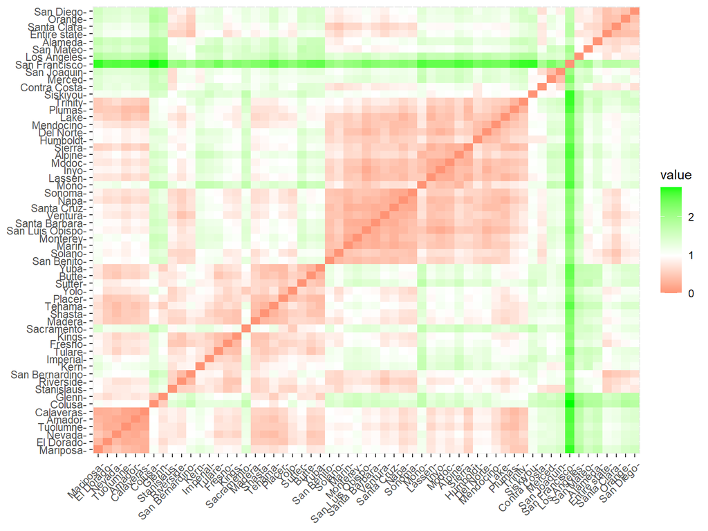

```r
fviz_dist(distance, order = TRUE, gradient = list(low = "red", mid = "white", high = "green"))
```

4. Saving the cleaned dataset as a .csv (for SAS)

```r
# 4.1 - Write to a .csv file
write.csv(df_cea_agg_n, "Average_CancerRisk_per_County.csv", row.names=TRUE)
```

# Step 7 - Clustering techniques

### 7.1 - Hierarchical Clustering

```r
# 7.1.1 - Cluster Dendrogram
df_cea_agg.hclust <- hclust(distance)
df_cea_agg.hclust
```

```
##
## Call:
## hclust(d = distance)
##
## Cluster method   : complete
## Distance         : euclidean
## Number of objects: 59
```

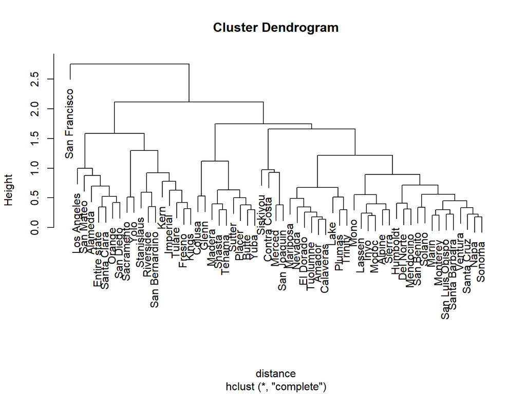

```r
plot(df_cea_agg.hclust)
```

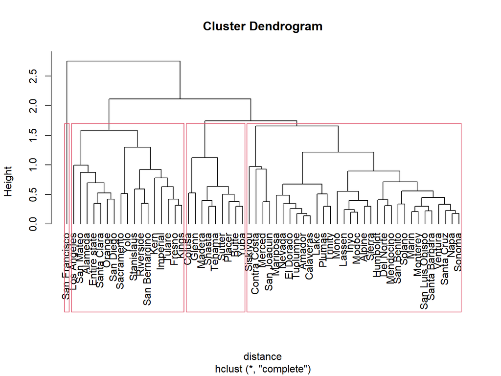

```r
plot(df_cea_agg.hclust,hang=-1)

rect.hclust(df_cea_agg.hclust, 4)
```

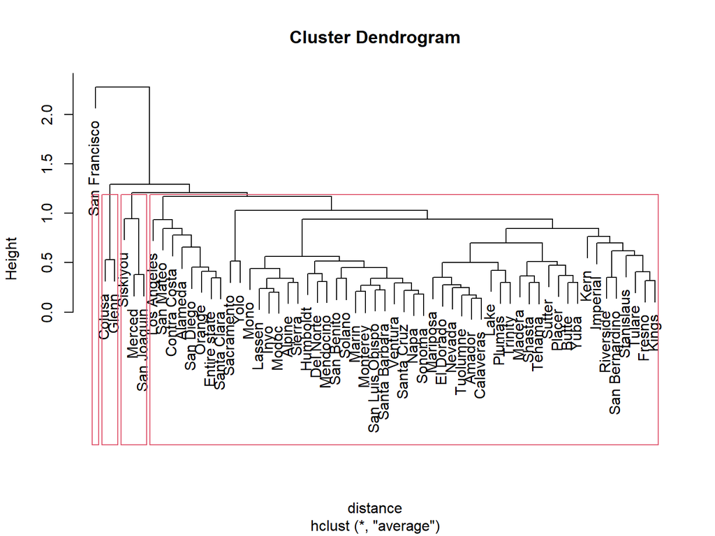

```r
# 7.1.2 Hierarchical clustering using average linkage
hclust.average <- hclust(distance, method = "average")
plot(hclust.average)
rect.hclust(hclust.average, 4)
```

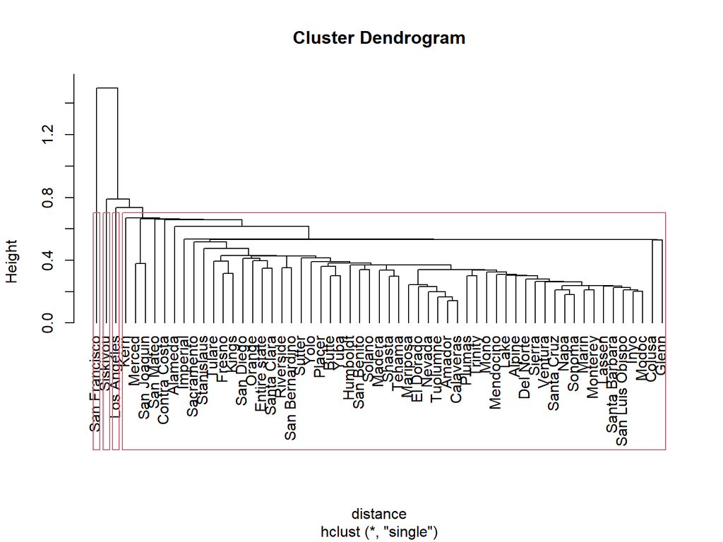

```r
# 7.1.3 Hierarchical clustering using single linkage
hclust.single <- hclust(distance, method = "single")
plot(hclust.single,hang = -1)
rect.hclust(hclust.single, 4)
```

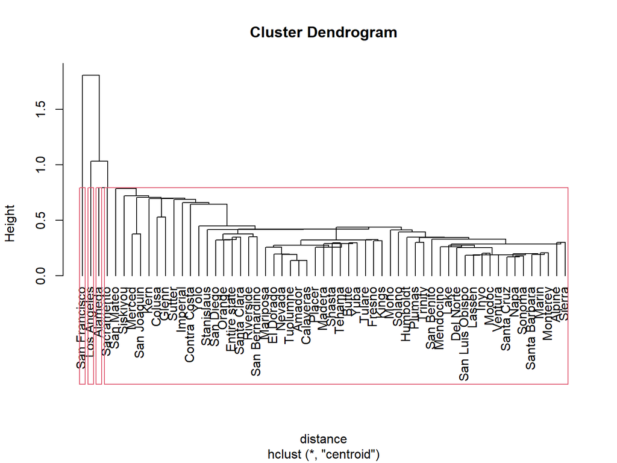

```r
# 7.1.4 Hierarchical clustering using centroid linkage
hclust.centroid <- hclust(distance, method = "centroid")
plot(hclust.centroid,hang = -1)
rect.hclust(hclust.centroid, 4)
```

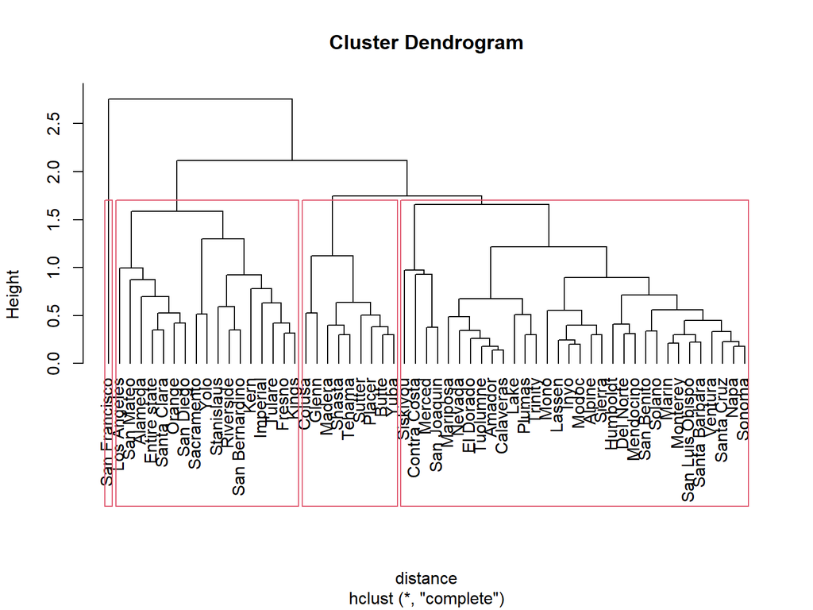

```r
# 7.1.5 Hierarchical clustering using complete linkage
hclust.complete <- hclust(distance, method = "complete")
plot(hclust.complete,hang = -1)
rect.hclust(hclust.complete, 4)
```

```r
# 7.1.6 Members of dendrogram
member.centroid <- cutree(hclust.centroid,4)
member.centroid
```

```
##         Alameda          Alpine          Amador           Butte       Calaveras
##               1               2               2               2               2
##          Colusa    Contra Costa       Del Norte       El Dorado    Entire state
##               2               2               2               2               2
##          Fresno           Glenn        Humboldt        Imperial            Inyo
##               2               2               2               2               2
##            Kern           Kings            Lake          Lassen     Los Angeles
##               2               2               2               2               3
##          Madera           Marin        Mariposa       Mendocino          Merced
##               2               2               2               2               2
##           Modoc            Mono        Monterey            Napa          Nevada
##               2               2               2               2               2
##          Orange          Placer          Plumas       Riverside      Sacramento
##               2               2               2               2               2
##      San Benito  San Bernardino       San Diego   San Francisco     San Joaquin
##               2               2               2               4               2
## San Luis Obispo       San Mateo   Santa Barbara     Santa Clara      Santa Cruz
##               2               2               2               2               2
##          Shasta          Sierra        Siskiyou          Solano          Sonoma
##               2               2               2               2               2
##      Stanislaus          Sutter          Tehama         Trinity          Tulare
##               2               2               2               2               2
##        Tuolumne         Ventura            Yolo            Yuba
##               2               2               2               2
```

```r
member.complete <- cutree(hclust.complete,4)
member.complete
```

```
##         Alameda          Alpine          Amador           Butte       Calaveras
##               1               2               2               3               2
##          Colusa    Contra Costa       Del Norte       El Dorado    Entire state
##               3               2               2               2               1
##          Fresno           Glenn        Humboldt        Imperial            Inyo
##               1               3               2               1               2
##            Kern           Kings            Lake          Lassen     Los Angeles
##               1               1               2               2               1
##          Madera           Marin        Mariposa       Mendocino          Merced
##               3               2               2               2               2
##           Modoc            Mono        Monterey            Napa          Nevada
##               2               2               2               2               2
##          Orange          Placer          Plumas       Riverside      Sacramento
##               1               3               2               1               1
##      San Benito  San Bernardino       San Diego   San Francisco     San Joaquin
##               2               1               1               4               2
## San Luis Obispo       San Mateo   Santa Barbara     Santa Clara      Santa Cruz
##               2               1               2               1               2
##          Shasta          Sierra        Siskiyou          Solano          Sonoma
##               3               2               2               2               2
##      Stanislaus          Sutter          Tehama         Trinity          Tulare
##               1               3               3               2               1
##        Tuolumne         Ventura            Yolo            Yuba
##               2               2               1               3
```

```r
table(member.centroid,member.complete)
```

```
##                member.complete
## member.centroid  1  2  3  4
##               1  1  0  0  0
##               2 15 32  9  0
##               3  1  0  0  0
##               4  0  0  0  1
```

### 7.2 K-Means Clustering

#### 1. Identify the optimal number of clusters

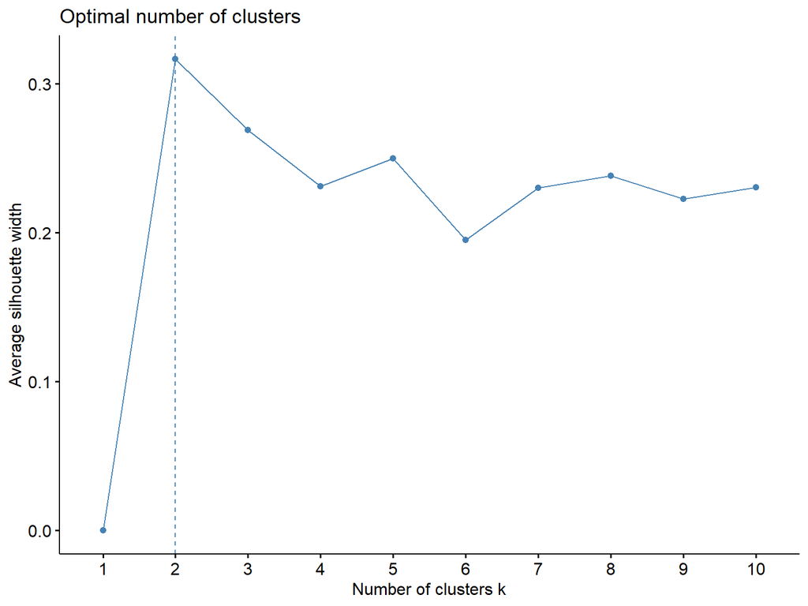

```r
# 7.2.1 - Scale the continuous data
scaled_df <- scale(df_cea_agg_n[,2:14])

# 7.2.2 - Calculate the Optimal number of clusters using factoextra package
fviz_nbclust(scaled_df, kmeans, method='silhouette')
```

#### 2. Plot the graphs to observe the distinction/overlap between the clusters.

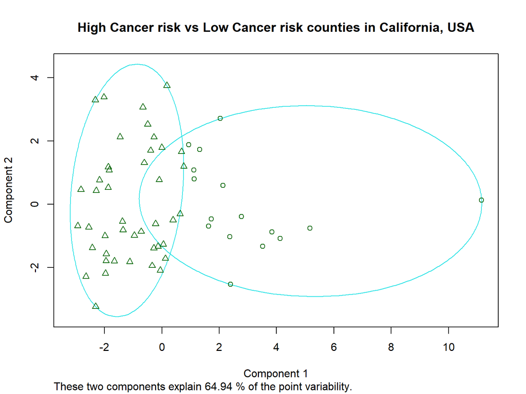

```r
# 7.2.3 - Apply the kmeans() algorithm based on the optimal no. of clusters
kclus <- kmeans(scaled_df, 2)$cluster

# 7.2.4 - Plot the graphs (without data points)
clusplot(scaled_df, kclus, main = "High Cancer risk vs Low Cancer risk counties in California, USA")
```

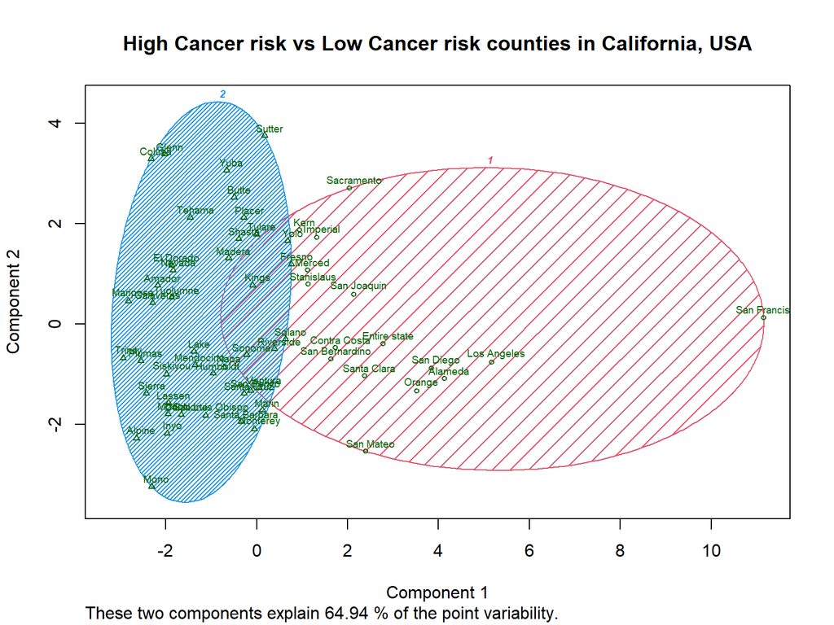

```r
# 7.2.5 - Plot the graphs (with data points)
clusplot(scaled_df, kclus, color = TRUE, shade = TRUE, cex=0.6, labels = 2, lines = 0, main = "High Cancer risk vs Low Cancer risk counties in California, USA")
```

# Step 8 - Model Evaluation

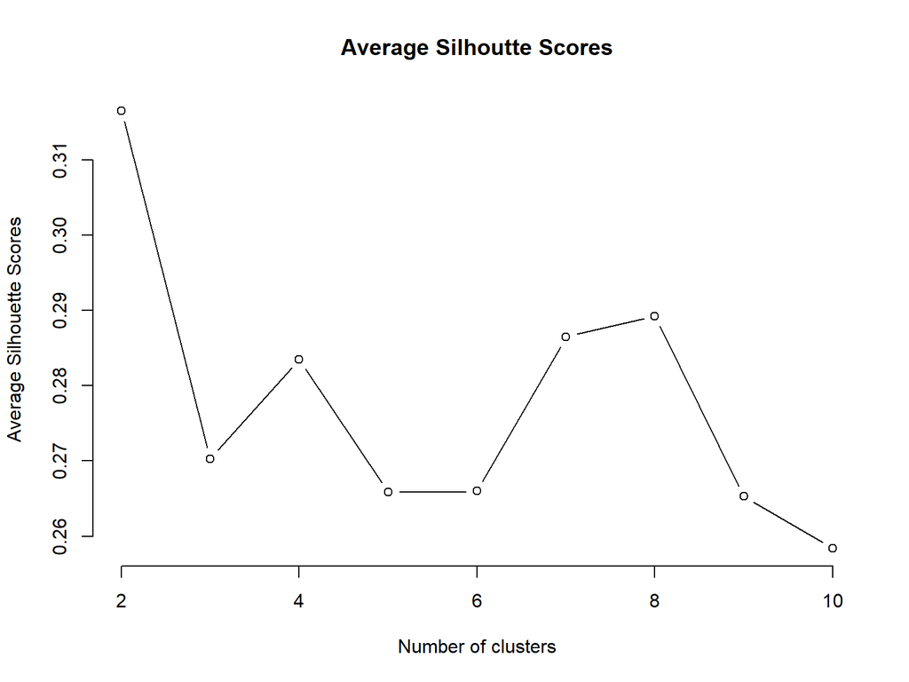

```r
# Silhoutte Score
silhouette_score <- function(k){
  km <- kmeans(scaled_df, centers = k, nstart=25)
  ss <- silhouette(km$cluster, dist(scaled_df))
  mean(ss[, 3])
}
k <- 2:10
avg_sil <- sapply(k, silhouette_score)
plot(k, type='b', avg_sil, main = 'Average Silhoutte Scores', xlab='Number of clusters', ylab='Average Silhouette Scores', frame=FALSE)
```